# Basis functions approximations for reduced-rank Gaussian process regresion: The uni-dimensional case

```r
library(viridis)
library(rstan)
library(rstanarm)
library(brms)
library(gtools)
```

Gaussian Processes are flexible non-parametric stochastic models for $D$-dimensional functions. However, a Gaussian process model suffer from observational dimensionality $(N)$, where the inversion of the covariance matrix requires of $O(N^3)$ computational expenses. This notebook deals with the implementation of an approximate eigendecomposition of the covariance function of a one-dimesional Gaussian process model. The method is based on interpreting the covariance function as the kernel of a pseudo-differential operator and approximating it using Hilbert space methods. This results in a reduced-rank approximation for the covariance function (Solin and Särkkä, 2018), and the computational requeriments becomes $O(N\cdot M + M)$, where M is the number of basis functions used in the approximation. Comparison of this approximated framework with the full Gaussian process and a splines-based model is carried out.

## Simulated data

True function from which simulate noisy observations.

```r
F <- function(x) 1/10*(x/10+1.7)^3 - 2/5*(x/10+1.7)^2 + 1/5*sin((x/10+1.7)^3)
```

```r
x <- seq(-5,5,0.1)
N <- length(x)
set.seed(4321)
y <-  F(x) + rnorm(N, 0, 0.08)
```

We choose $N1$ observations out of the $N$ observations to be the training data set, and $N2$ out of the $N$ observations to be the test. The objects $ind1$ and $ind2$ contain the indices of the training and test data, respectively.

```r
vv2 <- (x>(-1)&x<1.2)|x>3.8
ind1= which(!vv2)
ind2= which(vv2)
N1= length(ind1)
N2= length(ind2)
```

The following figure shows the true function and the simulated noisy observations. The vertical grey dashed lines divide the training and test observations.

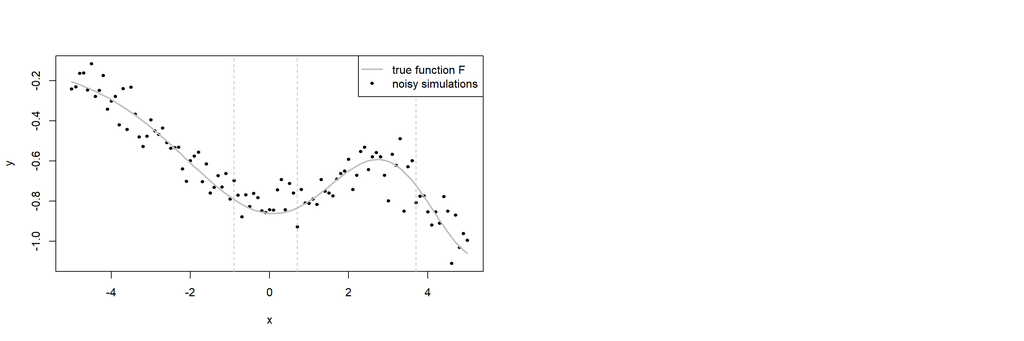

```r
par(mfrow=c(1,2))
plot(x, y, cex=0.6, pch=19)
lines(x, F(x), lwd=2, col="grey")
abline(v=c(x[ind2[1]],x[ind2[17]],x[ind1[N1]]), lty=2, col="grey")
legend("topright", legend=c("true function F","noisy simulations"), lty=c(1,NA), lwd=c(2,NA), pch=c(NA,19), pt.cex=c(NA,0.6), col=c("grey",1), cex=1)
```

### Gaussian process model

First of all, we model and adjust the noisy observations using a Gaussian process model. The noisy observations $\mathbf{y}$ are modelled as an underlying latent Gaussian process prior model $\mathbf{f}$ plus a Gaussian noise $\mathbf{e}$, and estimated using Bayesian inference with Hamiltion Monte Carlo (HMC) methods.

$$\mathbf{f} \sim \text{GP}(0,k(\mathbf{x};\theta))$$
$$\mathbf{y} = \mathbf{f} + \mathbf{e}$$
$$\mathbf{e} \sim \mathtt{N}(0,\sigma^2I)$$
We use, for instant, the squared exponential covariance function $k$:

$$k(x,x';\theta)=\alpha^2 \exp\left( -\frac{1}{2\rho^2}(x-x')^2\right)$$

```r
cov_GP <- function(alpha, rho, d) { alpha^2*exp(-1/(2*rho^2)*d^2) }
```

The following figure shows the covariance function $k$ as a function of $d=|x-x'|$, for different values of the lengthscale $\rho=\{0.1,0.3,0.5,1,2,4\}$, and for the magnitud $\alpha=1$:

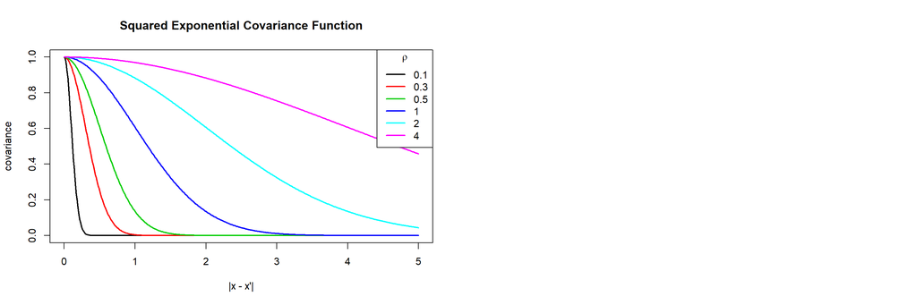

```r
rho <- c(0.1,0.3,0.5,1,2,4)     #lengthscale
alpha <- 1                      #magnitud

d <- seq(0,5,0.01)
COV_GP <- matrix(NA,length(d),length(rho))
for(i in 1:length(rho)){
  COV_GP[,i] <- cov_GP(alpha, rho[i], d)
}

par(mfrow=c(1,2))
matplot(d, COV_GP, col=1:length(rho), lwd=2, type="l", lty=1, main="Squared Exponential Covariance Function", cex.lab=1, ylab="covariance", xlab="|x - x'|")
legend("topright", legend=as.character(rho), col=1:length(rho), lty=c(1), lwd=2, title=expression(rho), cex=1)
```

Data for Stan software.

```r
standata_GP <- list(x= as.matrix(x), y= y, N= N, ind1= ind1, N1= N1, ind2= ind2, N2= N2)
```

The Stan code for the regular Gaussian process model: ‘https://github.com/gabriuma/basis_functions_approach_to_GP/blob/master/uni_dimensional/simulated_dataset/stancode_GP_1dim.stan’

Adjust the model using Stan software and the function ‘stan’ from the R-package ‘rstan’.

```r
stanout_GP <- stan(file= ".../stancode_GP_1dim.stan", data= standata_GP, iter= 1000,  warmup= 500, chains= 2, thin= 1, algorithm= "NUTS")
```

Store the estimates of the hyperparameters $\alpha$ (magnitud) and $\rho$ (lengthscale), the posterior of the latent function $f$, the predictions for training and test data, and the log predictive densities for the test data, in separated objects. Histograms and autocorrelation plots of the hyperparameters $alpha$, $rho$, and $sigma$ are shown.

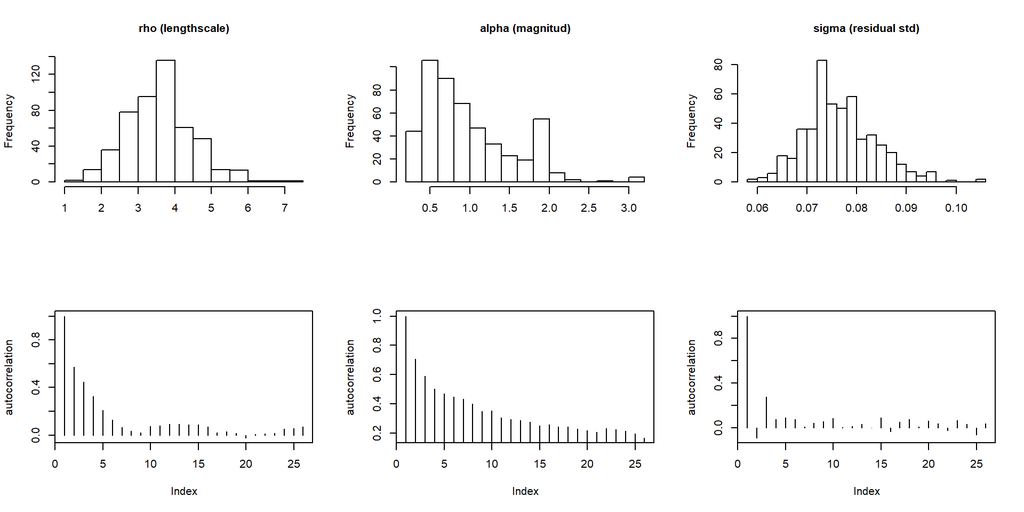

```r
alpha_GP <- summary(stanout_GP, pars = c("alpha"), probs = c(0.025, 0.5, 0.975), digits_summary = 4)$summary
rho_GP <- summary(stanout_GP, pars = c("rho"), probs = c(0.025, 0.5, 0.975), digits_summary = 4)$summary
sigma_GP <- summary(stanout_GP, pars = c("sigma"), probs = c(0.025, 0.5, 0.975), digits_summary = 4)$summary
f_GP <- summary(stanout_GP, pars = c("f"), probs = c(0.025, 0.5, 0.975), digits_summary = 4)$summary
y_predict_GP <- summary(stanout_GP, pars = c("y_predict"), probs = c(0.025, 0.5, 0.975), digits_summary = 4)$summary
log_y_predict_GP <- summary(stanout_GP, pars = c("log_y_predict"), probs = c(0.025, 0.5, 0.975), digits_summary = 4)$summary

par(mfcol=c(2,3))
hist(extract(stanout_GP, pars=c("rho"))$rho, main="rho (lengthscale)", xlab="", cex.lab=1, cex.main=1, breaks=20, cex.main=1)
plot(stan_ac(stanout_GP, pars = c("rho"))$data$ac, type="h", ylab="autocorrelation")
hist(extract(stanout_GP, pars=c("alpha"))$alpha, main="alpha (magnitud)", xlab="", cex.lab=1, cex.main=1, breaks=20, cex.main=1)
plot(stan_ac(stanout_GP, pars = c("alpha"))$data$ac, type="h", ylab="autocorrelation")
hist(extract(stanout_GP, pars=c("sigma"))$sigma, main="sigma (residual std)", xlab="", cex.lab=1, cex.main=1, breaks=20, cex.main=1)
plot(stan_ac(stanout_GP, pars = c("sigma"))$data$ac, type="h", ylab="autocorrelation")
```

Computing the mean square error, the expected log predictive density, and the time of computation in seconds per iteration for test data. The effective number of samples for the hyper-parameters and the latent function are also computed. Plots of these quantities will be shown further in this notebook.

```r
mse_GP <- sqrt(sum((y[ind2] - y_predict_GP[ind2])^2)/N2)
elpd_GP <- sum(log_y_predict_GP[ind2,1])/N2
time_GP <- get_elapsed_time(stanout_GP)[2]/(stanout_GP@sim$iter - stanout_GP@sim$warmup)

neff_alpha_GP <- alpha_GP[,7]/(stanout_GP@sim$iter - stanout_GP@sim$warmup)
neff_rho_GP <- rho_GP[,7]/(stanout_GP@sim$iter - stanout_GP@sim$warmup)
neff_f_GP <- mean(f_GP[,7])/(stanout_GP@sim$iter - stanout_GP@sim$warmup)
neff_sigma_GP <- mean(sigma_GP[,7])/(stanout_GP@sim$iter - stanout_GP@sim$warmup)
```

The following figures show the predictive distribution for training and test data, superimposed to the true function and observations. The vertical grey dashed lines divide the training and test observations.

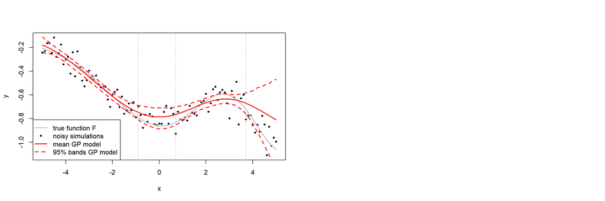

```r
par(mfrow=c(1,2))
plot(x, y, cex=0.6, pch=19)
lines(x, F(x), lwd=2, col="grey")
matplot(x, cbind(f_GP[,1],f_GP[,c(4,6)]), add=TRUE, col=2, type="l", lty=c(1,2,2), lwd=2)
abline(v=c(x[ind2[1]],x[ind2[17]],x[ind1[N1]]), lty=2, col="grey")
legend("bottomleft", legend=c("true function F","noisy simulations","mean GP model","95% bands GP model"), lty=c(1,NA,1,2), lwd=c(2,NA,2,2), pch=c(NA,19,NA,NA), pt.cex=c(NA,0.6,NA,NA), col=c("grey",1,2,2), cex=1)
```

### Basis functions approximation to a Gaussian process model

The Hilbert space approximations for the covariance operator leads to the approximation of the covariance function $k(x,x')$ in the form:

$$k(x,x')=\sum_m S(\sqrt{\lambda_m}) \cdot \phi_m(x) \cdot \phi_m(x').$$

In the previous equation, $\phi_m(x)$ is the $m$’th eigenfunction of the Laplacian,

$$\phi_m(x)=L^{-1/2} \cdot \sin(\frac{\pi m}{2L} (x+L)),$$

```r
phi <- function(L, m, x) { 1/sqrt(L)*sin((m*pi)/(2*L) * (x+L)) }
```

and $S(\sqrt(\lambda_m))$ is the spectral density, as a function of $\sqrt(\lambda_m)$, of the squared exponential covariance function $k$,

$$S(\sqrt{\lambda_m})=\alpha^2\sqrt{2\pi}\cdot\rho\cdot e^{-0.5\rho^2 \sqrt{\lambda_m}^2},$$

```r
spd <- function(alpha, rho, w) { (alpha^2)*sqrt(2*pi)*rho*exp(-0.5*(rho^2)*(w^2)) }
```

and $\lambda_m$ is the $m$’th eigenvalue,

$$\lambda_m =(\frac{\pi m}{2L})^2,$$

```r
lambda <- function(L,m) { ((m*pi)/(2*L))^2 }
```

where $m=1,\dots,M$, with $M$ the number of basis functions, and $L$ is the extended range of the input data so that $x\in \{L,-L\}$.

The following figure shows the set of the first 5 basis functions $\phi_m$ ($m=1,\dots,M=5$) with $L= \frac{5}{2}\cdot \max(\mathbf{x})$.

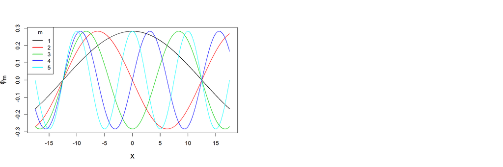

```r
L <- 5/2*max(x)
M <- 5

vv <- seq(min(x)-L, max(x)+L,0.01)
PHI <- matrix(NA,length(vv),M)
for (m in 1:M){ PHI[,m] = phi(L, m, vv); }

par(mfrow=c(1,2))
matplot(vv, PHI, type="l", lty=1, col=1:M, ylab=expression(phi[m]), xlab="x", cex.lab=1.5)
legend("topleft", legend=as.character(1:M), col=1:M, lty=1, title="m", lwd=2)
```

The values of the spectral density $S(\sqrt(\lambda_m))$, as a function of $m$ $(m=1,\cdots,M)$, for different values of the lengthscale $\rho$, and a fixed value of $\alpha=1$.

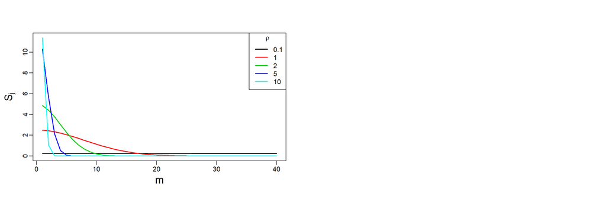

```r
L <- 5/2*max(x)
M <- 40
alpha <- 1
rho <- c(0.1,1,2,5,10)
S <- matrix(NA, M, length(rho))
for (i in 1:length(rho)){ S[,i] = spd(alpha, rho[i], sqrt(lambda(L, 1:M))); }

par(mfrow=c(1,2))
matplot(1:M, S, type="l", pch=1, lty=1, lwd=2, ylab=expression(S[j]), xlab="m", cex.lab=1.5, col=1:length(rho), mgp= c(2, 0.5, 0))
legend("topright", legend=as.character(rho), col=1:length(rho), lty=1, lwd=2, title=expression(rho))
```

In this way, the full covariance matrix $K(\mathbf{x})$ of the Gaussian process can be approximated as:

$$K(X,X')=\Phi \Delta \Phi^\intercal,$$

```r
covfun_BF <- function(M, alpha, rho, L, x) {
    cc <- vector()
    for(m in 1:M){
        cc[m] <- spd(alpha, rho, sqrt(lambda(L,m))) * phi(L, m, 0) * phi(L, m, x)
    }
    sum(cc);
}
```

where $\Phi \in \mathbb{R}^{N\times M}$ is the matrix of eigenvalues $\phi_m(x)$ with $m=1,\cdots,M$ and $x\in \mathbb{R}^N$,

$$\Phi=
\left[ {\begin{array}{ccc}
\phi_1(x^1) & \cdots & \phi_M(x^1) \\
\vdots &\ddots & \vdots \\
\phi_1(x^N) & \cdots & \phi_M(x^N) \\
\end{array} } \right],$$
and $\Delta \in \text{diag}(\mathbb{R}^{M\times M})$ is the diagonal matrix with the spectral density of the $M$ eigenvalues

$$\Delta =
\begin{bmatrix}
S(\sqrt{\lambda_1}) & & \\
& \ddots & \\
& & S(\sqrt{\lambda_M})
\end{bmatrix}$$

Now, we can re-define the Gaussian process model as

$$\mathbf{y} \sim \text{GP}(0,\Phi \Delta \Phi^\intercal + \sigma^2 I),$$
which implies the observation model to be

$$\mathbf{y} = \Phi \Delta^{1/2} \mathbf{\beta} + \mathbf{e},$$
where

$$\mathbf{\beta} \sim \mathtt{N}(0,I); \hspace{5mm} I\in \mathbb{R}^{M\times M}$$
$$\mathbf{e} \sim \mathtt{N}(0,\sigma^2 I); \hspace{5mm} I\in \mathbb{R}^{N\times N}$$
The aproximate covariance functions for different number of basis functions $M$, with specific values of the hyperparameters $\alpha=1$ and $\rho=1$, and with $L= \frac{5}{2}\cdot \max(\mathbf{x})$:

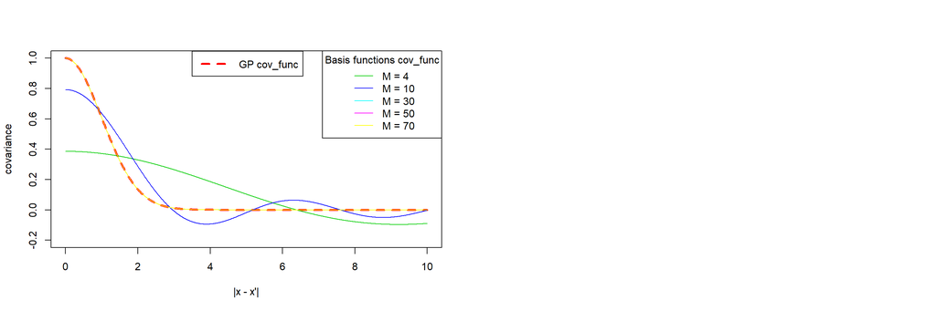

```r
M <- c(4,10,30,50,70)  #different number of basis functions
alpha <- 1
rho <- 1
L <- 5/2*max(x)

d <- seq(0,rho*10,0.01)
cov_BF <- matrix(NA, length(d), length(M))
for(m in 1:length(M)){
    for(i in 1:length(d)){
        cov_BF[i,m] <- covfun_BF(M[m], alpha, rho, L, d[i])
    }
}

par(mfrow=c(1,2))
plot(d, cov_GP(alpha, rho, d), col=2, lwd=3, type="l", lty=2, ylim=c(-0.2,1), ylab="covariance", cex.main=0.8, xlab="|x - x'|")
matplot(d, cov_BF, type="l", add=TRUE, col=c(3:(2+length(M))), lty=1)
legend("topright", legend=paste("M =",as.character(M)), col=c(3:(2+length(M))), lty=1, lwd=1, title="Basis functions cov_func")
legend(x=3.5, y=1.045, legend="GP cov_func", col=2, lty=2, lwd=3, seg.len=3)
```

#### Application to the simulated dataset:

We are going to apply this reduced-rank GP model to the simulated dataset. First of all, we stablish a collection of different values for the number of basis functions in the approximation, in order to find out which is the optimal number of basis functions to aproximate the full covariance matrix.

```r
M <- c(2,4,6,10,20,30,40)  #different number of basis functions
M
```

```
## [1]  2  4  6 10 20 30 40
```

Different datasets for the Stan software are defined, one for each one of the different numbers of basis functions. We establish a set of observations for training $N1$ and another one for test $N2$, out of the total number of observations $N$. The object $ind1$ contains the indices for the training data.

```r
standata_BF <- list()
for(j in 1:length(M)){  # different numbers of basis functions
  standata_BF[[j]] <- list(M= M[j], L= 5/2*max(x), x= x, y= y, N= N, ind1= ind1, N1= N1, ind2= ind2, N2= N2)
}
```

The Stan code for the reduced-rank Gaussian process model: ‘https://github.com/gabriuma/basis_functions_approach_to_GP/blob/master/uni_dimensional/simulated_dataset/stancode_BF_1dim.stan’

Adjust the model using Stan software and the function ‘stan’ from the R-package ‘rstan’. Different adjustments are performed, one for each one of the different numbers of basis functions.

```r
stanout_BF <- list()
for(j in 1:length(M)){  #different number of basis functions
stanout_BF[[j]] <- stan(file = ".../stancode_BF_1dim.stan", data= standata_BF[[j]], iter= 10000,  warmup= 5000, chains= 1, thin= 1, algorithm= "NUTS", verbose= FALSE)
}
```

Store the results for the hyperparameters $\alpha$ (magnitud), $\rho$ (lengthscale), and $sigma$ (residual std), the posterior distribution of the latent function $f$, the predictive distribution for training and test data, and the log predictive densities for the test data. Plots of these three parameters, $\alpha$, $\rho$, and $sigma$ as a function of the mnumber of basis functions are conputed.

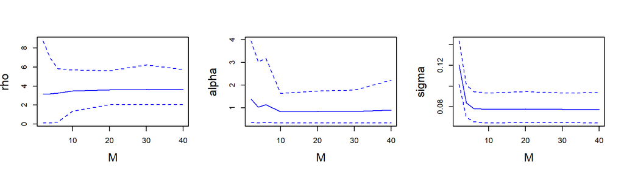

```r
f_BF <- list()
y_predict_BF <- list()
log_y_predict_BF <- list()
rho_BF <- matrix(NA,length(M),8)
alpha_BF <- matrix(NA,length(M),8)
sigma_BF <- matrix(NA,length(M),8)

par(mfrow=c(1,3))
for(j in 1:length(M)){  #different number of basis functions
    f_BF[[j]] <- summary(stanout_BF[[j]], pars = c("f"), probs = c(0.025, 0.5, 0.975), digits_summary = 4)$summary
    y_predict_BF[[j]] <- summary(stanout_BF[[j]], pars = c("y_predict"), probs = c(0.025, 0.5, 0.975), digits_summary = 4)$summary
    log_y_predict_BF[[j]] <- summary(stanout_BF[[j]], pars = c("log_y_predict"), probs = c(0.025, 0.5, 0.975), digits_summary = 4)$summary

    rho_BF[j,] <- summary(stanout_BF[[j]], pars = c("rho"), probs = c(0.025, 0.5, 0.975), digits_summary = 4)$summary
    alpha_BF[j,] <- summary(stanout_BF[[j]], pars = c("alpha"), probs = c(0.025, 0.5, 0.975), digits_summary = 4)$summary
    sigma_BF[j,] <- summary(stanout_BF[[j]], pars = c("sigma"), probs = c(0.025, 0.5, 0.975), digits_summary = 4)$summary
}

matplot(M,rho_BF[,c(1,4,6)], xlab="M", type="l", lty=c(1,2,2), col=4, ylab="rho", cex.lab=1.5)
matplot(M,alpha_BF[,c(1,4,6)], xlab="M", type="l", lty=c(1,2,2), col=4, ylab="alpha", cex.lab=1.5)
matplot(M,sigma_BF[,c(1,4,6)], xlab="M", type="l", lty=c(1,2,2), col=4, ylab="sigma", cex.lab=1.5)
```

Histogram plots of these three parameters, $\alpha$, $\rho$, and $sigma$.

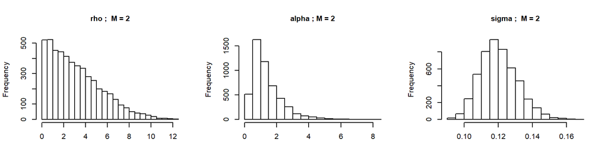

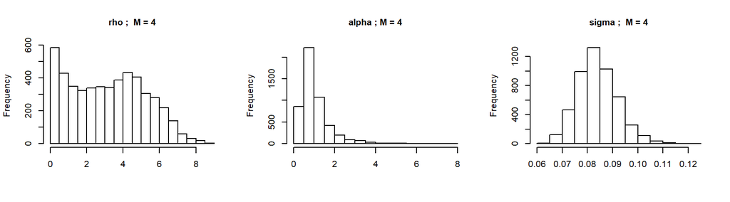

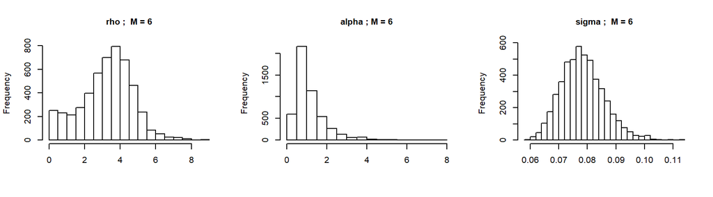

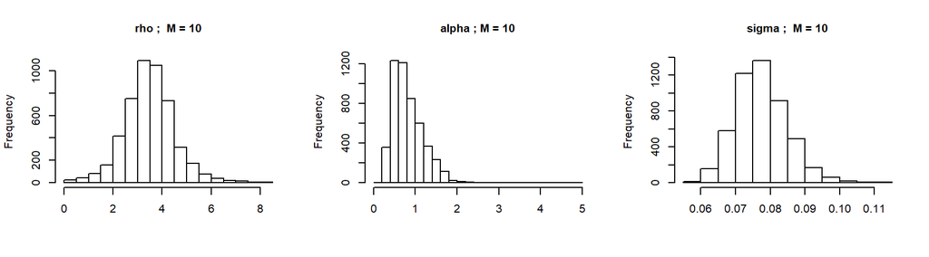

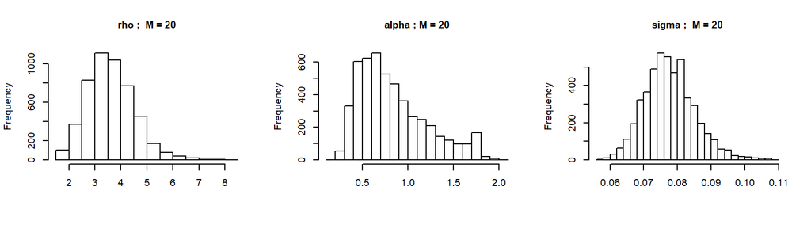

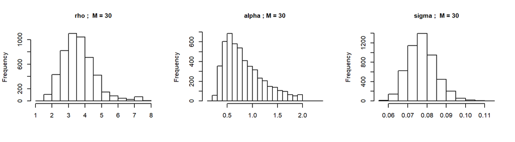

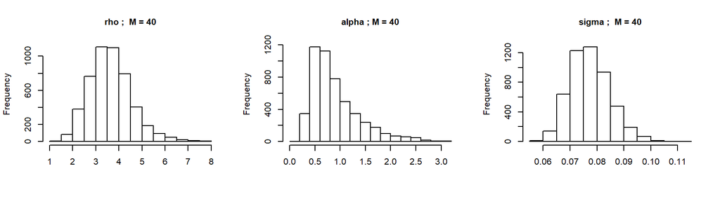

```r
par(mfrow=c(1,3))
for(j in 1:length(M)){
    hist(extract(stanout_BF[[j]], pars=c("rho"))$rho, main=paste("rho ;  M =",M[j]), xlab="", cex.lab=1, cex.main=1, breaks=20, cex.main=1)
    hist(extract(stanout_BF[[j]], pars=c("alpha"))$alpha, main=paste("alpha ; M =",M[j]), xlab="", cex.lab=1, cex.main=1, breaks=20, cex.main=1)
      hist(extract(stanout_BF[[j]], pars=c("sigma"))$sigma, main=paste("sigma ;  M =",M[j]), xlab="", cex.lab=1, cex.main=1, breaks=20, cex.main=1)
}
```

Autocorrelation plots of these three parameters, $\alpha$, $\rho$, and $sigma$ are conputed.

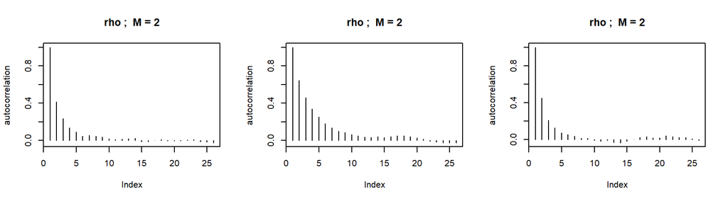

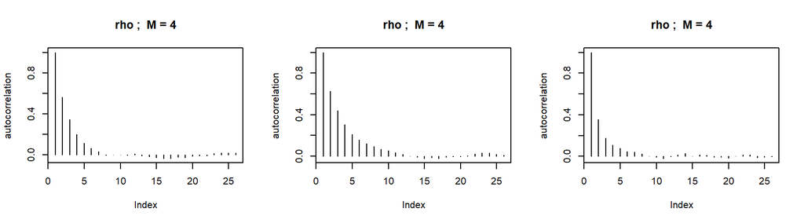

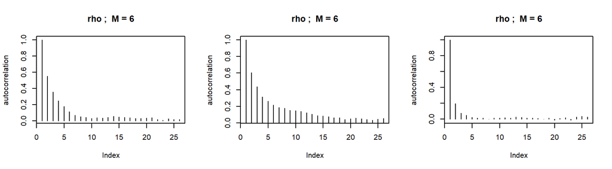

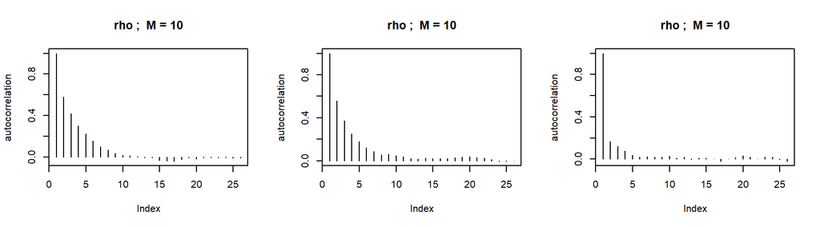

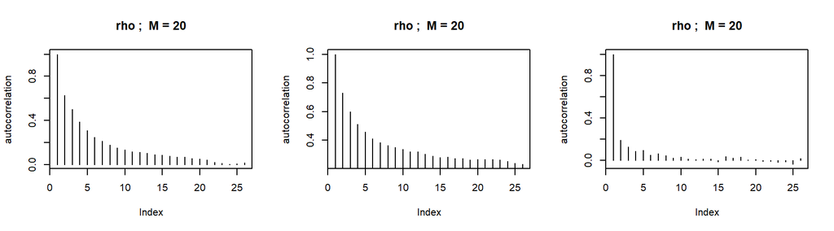

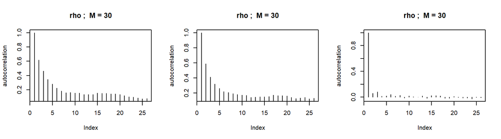

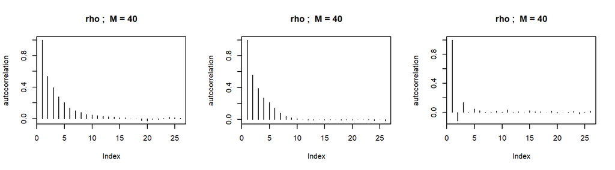

```r
par(mfcol=c(1,3))
for(j in 1:length(M)){
    plot(stan_ac(stanout_BF[[j]], pars = c("rho"))$data$ac, type="h", ylab="autocorrelation", main=paste("rho ;  M =",M[j]))
    plot(stan_ac(stanout_BF[[j]], pars = c("alpha"))$data$ac, type="h", ylab="autocorrelation", main=paste("rho ;  M =",M[j]))
      plot(stan_ac(stanout_BF[[j]], pars = c("sigma"))$data$ac, type="h", ylab="autocorrelation", main=paste("rho ;  M =",M[j]))
}
```

```r
mse_BF <- vector()
elpd_BF <- vector()
time_BF <- vector()
msegp_BF <- vector()
neff_alpha_BF <- vector()
neff_rho_BF <- vector()
neff_f_BF <- vector()
neff_sigma_BF <- vector()
for(j in 1:length(M)){  #different number of basis functions
  mse_BF[j] <- sqrt(sum((y[ind2] - y_predict_BF[[j]][ind2])^2)/N2)
  elpd_BF[j] <- sum(log_y_predict_BF[[j]][ind2,1])/N2
  time_BF[j] <- get_elapsed_time(stanout_BF[[j]])[2]/(stanout_BF[[j]]@sim$iter - stanout_BF[[j]]@sim$warmup)

  msegp_BF[j] <- sqrt(sum((y_predict_GP[[j]][ind2] - y_predict_BF[[j]][ind2])^2)/N2)

  neff_alpha_BF[j] <- alpha_BF[j,7]/(stanout_BF[[j]]@sim$iter - stanout_BF[[j]]@sim$warmup)
  neff_rho_BF[j] <- rho_BF[j,7]/(stanout_BF[[j]]@sim$iter - stanout_BF[[j]]@sim$warmup)
  neff_f_BF[j] <- mean(f_BF[[j]][,7])/(stanout_BF[[j]]@sim$iter - stanout_BF[[j]]@sim$warmup)
  neff_sigma_BF[j] <- mean(sigma_BF[j,7])/(stanout_BF[[j]]@sim$iter - stanout_BF[[j]]@sim$warmup)
}
```

In the following figure, we show the posterior values of the latent function $f$ for training and test data, as function of the number of basis functions $M$, jointly with the posteriors of the full Gaussian Process model. The vertical grey dashed line divide the training and test data sets.

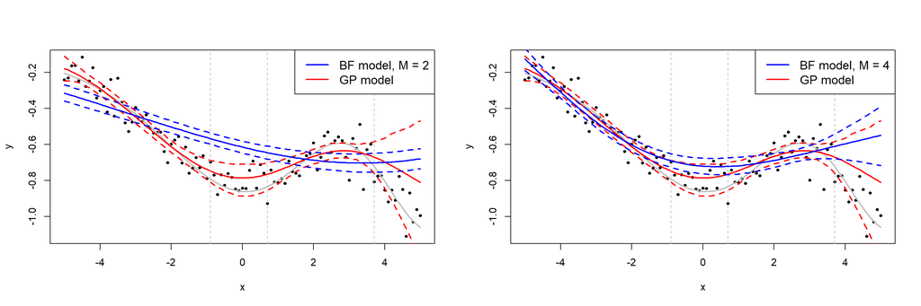

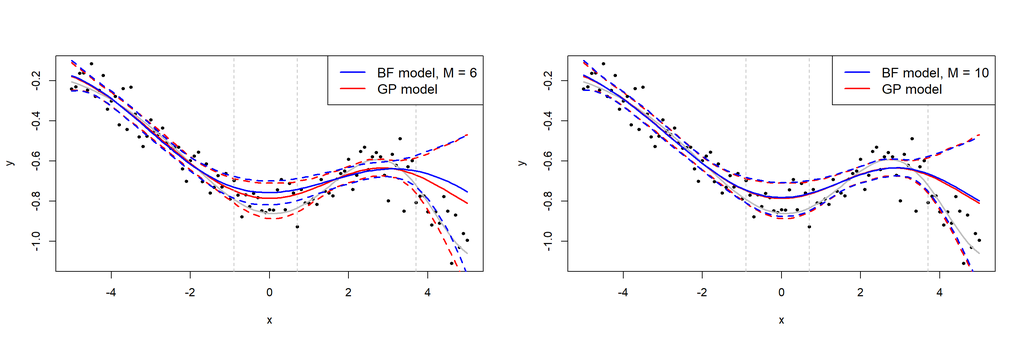

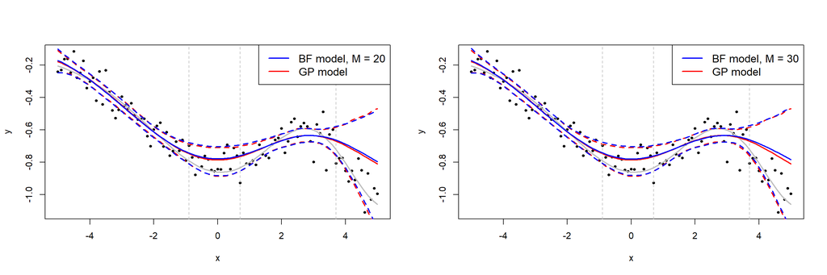

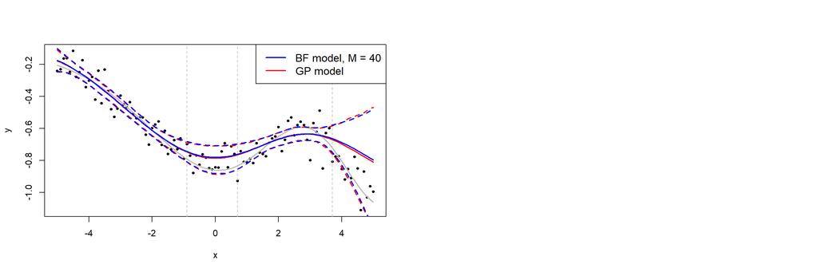

```r
par(mfrow=c(1,2))
for(j in 1:length(M)){
    # True function and observed data
    plot(x, y, cex=0.6, pch=19, xlab="x", ylab="y", cex.axis=1)
    lines(x, F(x), lwd=2, col="grey")
    #GP model
    matplot(x, cbind(f_GP[,1],f_GP[,c(4,6)]), add=TRUE, col=2, type="l", lwd=2, lty=c(1,2,2))
    abline(v=c(x[ind2[1]],x[ind2[17]],x[ind1[N1]]), lty=2, col="grey")
    #BF model
    matplot(x, cbind(f_BF[[j]][,1],f_BF[[j]][,c(4,6)]), add=TRUE, col=4, type="l", lty=c(1,2,2), lwd=2)

    legend("topright", legend=c(paste("BF model, M =",M[j]),"GP model"), lty=c(1), lwd=c(2,2), col=c(4,2), cex=1.2)
}
```

The following figure shows the aproximate covariance function for the different number of basis functions $M$, with the estimated values of $\alpha$ (magnitud) and $\rho$ (lengthscale):

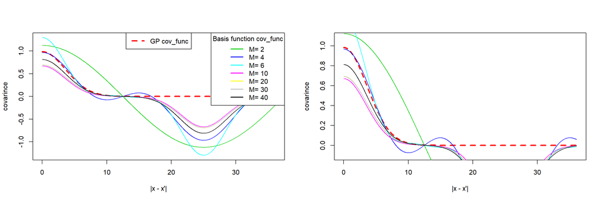

```r
L <- 5/2*max(x)

d <- seq(0,rho_GP[,1]*10,0.01)
cov_BF <- matrix(NA, length(d), length(M))
for(m in 1:length(M)){
    for(i in 1:length(d)){
        cov_BF[i,m] <- covfun_BF(M[m], alpha_BF[m,1], rho_BF[m,1], L, d[i])
    }
}

par(mfrow=c(1,2))
plot(d, cov_GP(alpha_GP[,1], rho_GP[,1], d), lty=2, col=2, lwd=3, type="l", ylim=c(min(cov_BF),max(cov_BF)), ylab="covarince", xlab="|x - x'|")
matplot(d, cov_BF, type="l", add=TRUE, col=c(3:(2+length(M))), lty=1)

legend("topright", legend=paste("M=",as.character(M)), col=c(3:(2+length(M))), lty=1, lwd=2, title="Basis function cov_func")
legend("top", legend="GP cov_func", col=2, lty=2, lwd=3)

plot(d, cov_GP(alpha_GP[,1], rho_GP[,1], d), lty=2, col=2, lwd=3, type="l", ylim=c(-0.1,0.1)+c(min(cov_GP(alpha_GP[,1], rho_GP[,1], d)),max(cov_GP(alpha_GP[,1], rho_GP[,1], d))), ylab="covarince", xlab="|x - x'|")
matplot(d, cov_BF, type="l", add=TRUE, col=c(3:(2+length(M))), lty=1)
```